# Visualización de datos relacionados con los pasajeros del Titanic

Elaborado por: Andreina Vásquez Castro B27084 (Tarea N° 3)

Fecha de ultima modificación 2024-04-19

- Librerías utilizadas:

```r
library("tidyverse")
library("ggplot2")
library("viridis")
library("psych")
library("stats")
library("datasets")
library("knitr")
library("dplyr")
library("readr")
```

# 1 Historia del Titanic

## 1.1 Introducción

### 1.1.1 Fotografías del Titanic del antes y despúes del naufragio.

En el año 1912 zarpó el barco más resistente, grande y lujoso de la época, la nave fue creada en conjunto por la naviera White Star Line, Bruce Ismay y los astilleros Harland & Wolff, se llamó “Titanic”. No obstante, a pocas horas de zarpar el barco colisionó con un iceberg que le ocasionó daños a la estructura y eventualmente su naufragio. En las siguientes imágenes se puede observar al Titanic antes de su naufragio, en estas se puede apreciar la dimensión del barco con respecto a personas u objetos alrededor. También, se observan los restos de la nave, los cuales se encuentran en el fondo del oceáno producto del naufragio, estas imágenes han sido capturadas en misiones con submarinos para documentar más la historia de esta nave, se observa como aún se mantiene en pie la estructura del barco y compartamientos en el interior.

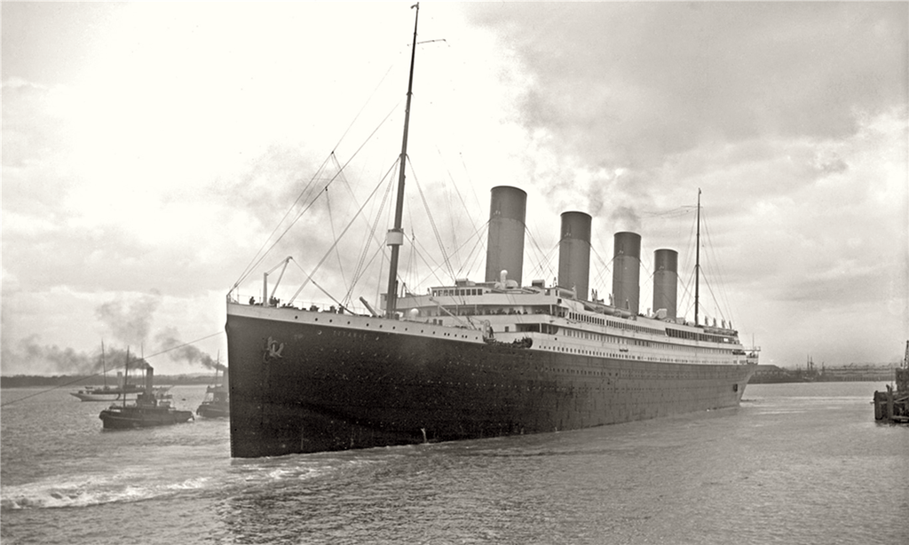

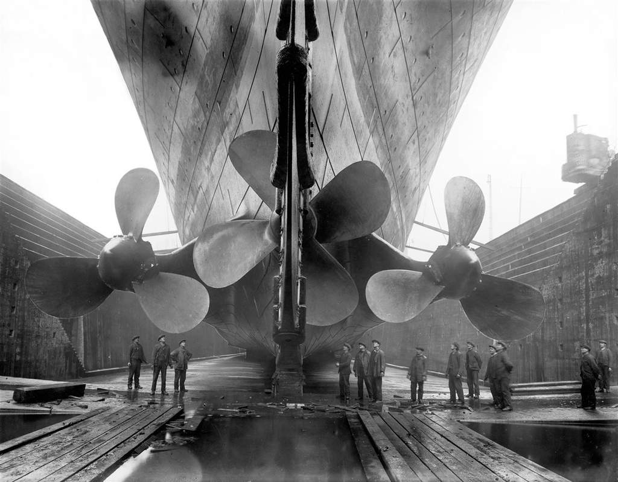

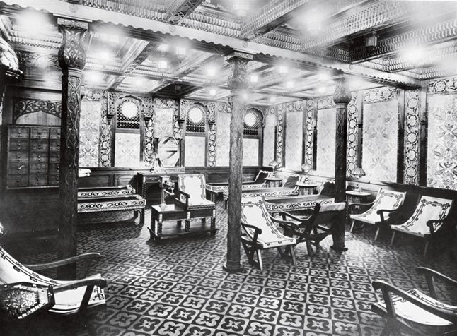

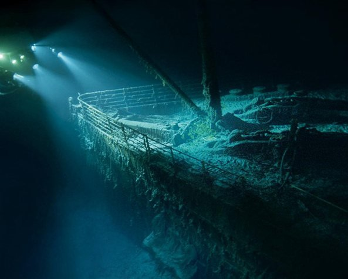

[figure not shown]

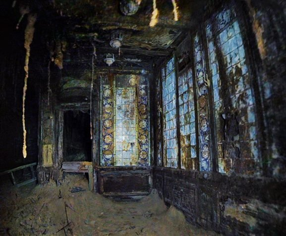

### 1.1.2 Datos históricos y expediciones recientes al Titanic

En un artículo llamado [“El Titanic, la historia completa de un naufragio histórico”](https://historia.nationalgeographic.com.es/a/historia-titanic-tragedia-barco-insumergible_16344) de National Geographic se puede conocer más sobre la historia del Titanic, desde su construcción hasta su naufragio en el año 1912. Como se mencionó anteriormente, actualmente, se han llevado a cabo muchas expediciones para conocer la situación actual de los restos de la nave, muchas han sido exitosas y han logrado mostrar lo que queda de la estructura del barco, sin embargo, recientemente sucedió una tragedia al implosionar un submarino que se dirigía a explorar el lugar del naufragio, sobre este suceso se puede consultar el siguiente articulo de la BBC: [Implosión del Titán](https://www.bbc.com/mundo/noticias-internacional-65994691).

Además, de la documentación fotográfica que existe del Titanic hay registros de los pasajeros donde se recopilan los nombres, la clase en la que viajaban, el costo del tiquete, el sexo, la edad, si sobrevivieron o murieron, entre otros. En este informe se presentará un pequeño análisis de los datos mostrados en la base de datos que contiene la información de los pasajeros, se observará la cantidad de sobrevivientes y decesos según la clase, la edad y el sexo, además, de contrastar la cantidad de pasajeros femininas y masculinos según la clase.

# 2 Base de datos con información de los pasajeros del Titanic

## 2.1 Variables de la base de datos

En la siguiente tabla se muestra la información de la base de datos que se utilizó para el análisis presente en este informe, en cada columna se muestra cada una de las variables que corresponden a una caracteristica importante de cada pasajero. A continuación se detalla el significado de cada una:

- Pasajero_ID: Identificador único de cada objeto de la base de datos.
- Sobrevivio: Idenitica si el pasajero vivió (1) o murió (0).
- Clase: Clase en la que viajaba el pasajero.
- Apellido: Apellido del pasajero.
- Nombre: Nombre del pasajero.
- Sexo: Femenino o masculino.
- Edad: Edad del pasajero.
- Hermano_conyugue: Cantidad de hermanos o cónyuges a bordo del Titanic.
- Padre_hijo: Cantidad de padres o hijos a bordo del Titanic.
- N_Tiquete: Número de tiquete.
- Tarifa: Costo del pasaje.
- N_Cabina: Número de cabina.
- Embarque: Puerto donde embarcó el pasajero.

Código para la tabla:

```r
encabezados <- c("Pasajero_ID","Sobrevivio","Clase","Apellido", "Nombre","Sexo", "Edad","Hermano_conyugue","Padre_hijo","N_Tiquete","Tarifa", "N_Cabina", "Embarque")
datos <- read.table(file="https://raw.githubusercontent.com/Andre9424/TAREA-3-LAB-PROBA-TITANIC/main/titanic.txt",
                    header=TRUE, sep=';', col.names = encabezados)

DT::datatable(datos,
              extensions = 'FixedColumns',
              rownames= FALSE,
              options = list(
                      pageLength = 5,
                      language = list(url = '//cdn.datatables.net/plug-ins/1.10.11/i18n/Spanish.json'),
                      autoWidth = TRUE,
                      scrollX = TRUE,
                      escape = T)
    )
```

| Pasajero_ID | Sobrevivio | Clase | Apellido | Nombre | Sexo | Edad | Hermano_conyugue | Padre_hijo | N_Tiquete | Tarifa | N_Cabina | Embarque |
| --- | --- | --- | --- | --- | --- | --- | --- | --- | --- | --- | --- | --- |
| 1 | 0 | 3 | Braund | Mr. Owen Harris | male | 22 | 1 | 0 | A/5 21171 | 7.25 |  | S |
| 2 | 1 | 1 | Cumings | Mrs. John Bradley (Florence Briggs Thayer) | female | 38 | 1 | 0 | PC 17599 | 71.2833 | C85 | C |
| 3 | 1 | 3 | Heikkinen | Miss. Laina | female | 26 | 0 | 0 | STON/O2. 3101282 | 7.925 |  | S |
| 4 | 1 | 1 | Futrelle | Mrs. Jacques Heath (Lily May Peel) | female | 35 | 1 | 0 | 113803 | 53.1 | C123 | S |
| 5 | 0 | 3 | Allen | Mr. William Henry | male | 35 | 0 | 0 | 373450 | 8.05 |  | S |
| 6 | 0 | 3 | Moran | Mr. James | male |  | 0 | 0 | 330877 | 8.4583 |  | Q |
| 7 | 0 | 1 | McCarthy | Mr. Timothy J | male | 54 | 0 | 0 | 17463 | 51.8625 | E46 | S |
| 8 | 0 | 3 | Palsson | Master. Gosta Leonard | male | 2 | 3 | 1 | 349909 | 21.075 |  | S |
| 9 | 1 | 3 | Johnson | Mrs. Oscar W (Elisabeth Vilhelmina Berg) | female | 27 | 0 | 2 | 347742 | 11.1333 |  | S |
| 10 | 1 | 2 | Nasser | Mrs. Nicholas (Adele Achem) | female | 14 | 1 | 0 | 237736 | 30.0708 |  | C |

[output cut: 1299 more lines]

## 2.2 Gráficos con información de los pasajeros

### 2.2.1 Distribución de los sobrevivientes según el género, la edad y la clase

Código para el primer gráfico:

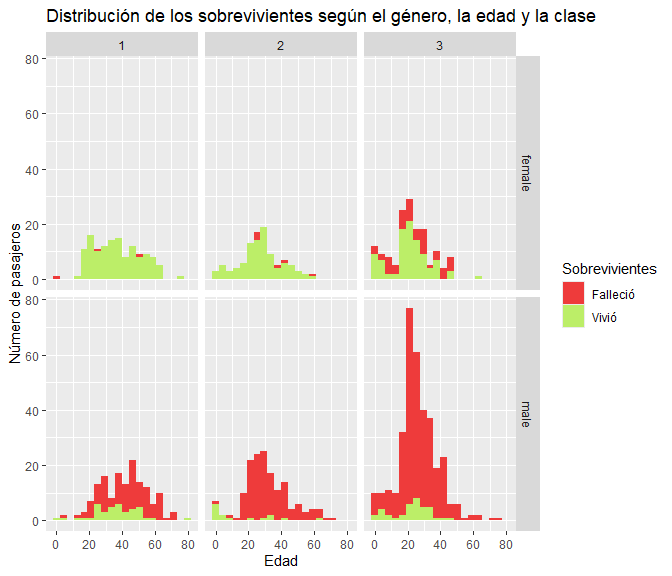

```r
ggplot(datos) +
  geom_histogram(bins=20, aes(x=Edad, fill = factor(Sobrevivio)))+
  facet_grid(cols=vars(Clase), rows=vars(Sexo))+
  labs(title = "Distribución de los sobrevivientes según el género, la edad y la clase",
       x = "Edad", y = "Número de pasajeros")+
  scale_fill_manual(values = c("#EE3B3B", "#BCEE68"),
                        name= "Sobrevivientes",
                        labels = c("Falleció","Vivió"))
```

Figura 1. Gráfico de distribución de los sobrevientes seguún el género, la edad y la clase.

### 2.2.2 Distribución de los pasajeros según clase y género

En el grafico de la figura 1 se observa que hay una mayor cantidad de hombres fallecidos en la tercera clase a diferencia de la primera clase, sin embargo, esto no quiere decir que se salvaron más personas de primera clase que de la tercera ya que si se observa el gráfico de la figura 2 se puede ver que la cantidad de mujeres y hombres de la tercera clase es mayor a la cantidad de personas de segunda y tercera clase por lo que comparando ambos gráficos se puede deducir que de toda la población en general tanto hombres como mujeres a bordo del barco la mayor cantidad de fallecidos pertenecian a la tercera clase, esta deducción se puede corroborar en el articulo de National Geographic [Las vidas truncadas del Titanic: Las historias de los sobrevivientes](https://historia.nationalgeographic.com.es/a/vidas-truncadas-titanic_11387). De este mismo grafico, figura 2, se puede observar, que a la segunda clase pertenecía una menor cantidad de personas tanto de hombres como de mujeres y contrastando con la figura 1, casi todos los hombres de esta clase fallecieron.

Código para el segundo gráfico:

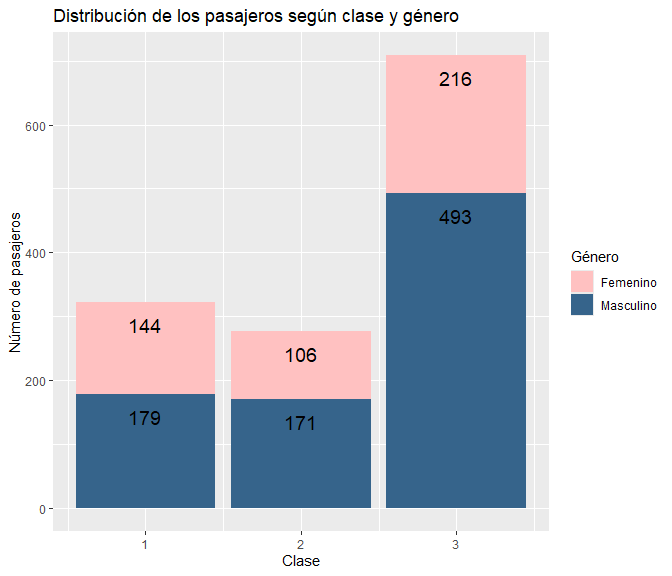

```r
ggplot(data = datos, aes(x = Clase, fill=Sexo), scale_x_discrete(labels=c("1", "2", "3"))) +
 geom_bar() +
  labs(title = "Distribución de los pasajeros según clase y género",
      x = "Clase", y = "Número de pasajeros") +
      scale_fill_manual(values = c("#FFC1C1", "#36648B"),
                        name= "Género",
                        labels = c("Femenino","Masculino")) +
        geom_text(stat = 'count',
                  aes(label = ..count..), position = "stack",
                  vjust = 2, size = 5, color = "black")
```

# 3 Información general

Este informe sobre la visualización y analisis de datos de los pasajeros del Titanic se realizó en RStudio, desde este software se generó un archivo autoreproducible en HTML el cual se puede consultar en linea en el siguiente enlace: [Informe sobre la visualización y analisis de la base de datos del Titanic](https://andre9424.github.io/TAREA-3-LAB-PROBA-TITANIC/) y en el siguiente enlace se accede a la base de datos del titanic para su consulta o descarga: [Base de datos](https://raw.githubusercontent.com/Andre9424/TAREA-3-LAB-PROBA-TITANIC/main/titanic.txt)

# 4 Conclusiones

A partir de los resultados anteriores y del proceso de realización de este informe se concluye lo siguiente:

## 4.1 Integración de R en la generación de informes

- La utilización de R para la generación de archivos autoreproducibles como informes sobre exploración y analisis de datos es una forma alternativa que permite integrar el formato de la presentación del documento y a su vez la manipulación de gráficos y tablas en un solo entorno, lo cual facilita la elaboración de informes y mejora la presentación del documento al tener control sobre la edición de todos los elementos.

## 4.2 Conclusiones sobre el analisis y visualización de la base de datos del Titanic

- El conjunto de personas adultas jovenes de género femenino fue el que tuvo más oportunidad de sobrevivir durante el naufragio del Titanic.
- El género masculino a nivel general tuvo más casos de fallecimientos en las tres clases de pasajeros.
- A bordo del barco hubieron más pasajeros pertenecientes a la tercera clase con respecto a la primera y segunda clase, a esta ultima pertenecia la cantidad menor de pasajeros por clase.
- De los pasajeros pertenecientes a la segunda clase murieron casi todos los hombres con respecto a la cantidad de mujeres que sobrevivieron.